# ETC5521 Assignment 1

All about Coffee

Siddhant V Tirodkar

Varsha Ujjinni Vijay Kumar

2020-08-28

This assignment is for ETC5521 Assignment 1 by Team Hakea comprising of Siddhant V Tirodkar and Varsha Ujjinni Vijay Kumar.

# Introduction and motivation

Coffee is the most popular beverage in the whole world. Let’s see, you’re reading this with a cup of coffee,aren’t you?

So wouldn’t it be interesting to know how the coffee you drink is graded to be either the best or bad coffee batches? The country with the best graded coffee beans and why are they considered the best, the different factors which elucidate the quality of the coffee cultivated. From where they come, the processing method to get them?

# Data description

*Source of data* : This data originally comes from Coffee Quality Institute website and was scraped by and used by a github account by [James DeLoux](https://github.com/jldbc/coffee-quality-database) ,this data was then re-posted on [Kaggle](https://www.kaggle.com/volpatto/coffee-quality-database-from-cqi?select=merged_data_cleaned.csv) . And this dataset was analysed by [Yorgos Askalidis](https://towardsdatascience.com/the-data-speak-ethiopia-has-the-best-coffee-91f88ed37e84).

*Collection Methods*: This dataset contains the review of 1312 arabica 28 robusta beans from the Coffee Quality Institute’s trained reviewers.

*Time Frame of dataset*: January 2018

The original data is a dataframe was scraped by James LeDoux from the Coffee Quality Institute website which has a few missing values columns within it, so the author has cleaned the dataset by removing the variables: “view_certificate_1”, “view_certificate_2”,etc.

Since both the datasets (Arabica and Robusta) are just two different species of coffee , they were joined to produce the dataset, which we now use “coffee_ratings.csv” with 1339 observations and 43 variables.

**Structure of data:**

After this knowing what each of those variables define with respect to our topic is important so here are a few variables we should know the general meaning to in accordance with coffee:

- *Aroma(aroma grade)* : Has both fragrance(ground beans) and aroma (hot water with coffee powder)
- *Aftertaste* : length of positive flavor remaining after the coffee is swallowed.
- *Acidity* : the score depends on the origin characteristics and other factors(degree of roast)
- *Uniformity* : refers to the consistency of flavor . 2 points are awarded for each cup displaying this attribute, with a maximum of 10 points if all 5 cups are the same.
- *Clean_cup* : refers to a lack of interfering negative impressions from first ingestion to final aftertaste, a “transparency” of cup. 2 points are awarded for each cup displaying the attribute.
- *Cupper-points* : The cupper marks the intensity of the Aroma on a scale. A final score for Fragrance and Aroma is now given on the basis of a combined evaluation of Fragrance and Aroma.
- *Category 1 defect*: Full black or sour bean, pod/cherry, and large or medium sticks or stones.
- *Category 2 defect*: Parchment, hull/husk, broken/chipped, insect damage, partial black or sour, shell, small sticks or stones, water damage.
- *Quakers*: Quakers are unripened beans that are hard to identify during hand sorting and green bean inspection.

**Questions:**

- Which Country produces the best quality coffee beans?
- Does Altitude really affect the quality of the beans produced?
- Which countries perform best on individual grading criteria such as aroma, acidity, sweetness etc?
- Which regions/companies perform better than others in the quality of the coffee beans produced, intra-country?

# Explatory Data Analysis

Coffee beans are harvested, produced and exported throughout almost every country in the world. This dataset contains the data of Ethiopia, Guatemala, Brazil, Peru, United States, United States (Hawaii), Indonesia, China, Costa Rica, Mexico, Uganda, Honduras, Taiwan, Nicaragua, Tanzania, United Republic Of, Kenya, Thailand, Colombia, Panama, Papua New Guinea, El Salvador, Japan, Ecuador, United States (Puerto Rico), Haiti, Burundi, Vietnam, Philippines, Rwanda, Malawi, Laos, Zambia, Myanmar, Mauritius, Cote d?Ivoire, NA, India. We will be focusing on the manufacturing and the quality aspect of the beans produced in this report. The two main variants of a coffee bean are Arabica and Robusta. Approximately 60% of coffee produced in the world is Arabica and approximately 40% is Robusta. Arabica beans consists about 0.8%-1.4% caffeine and Robusta beans consists of 1.7%-4% caffeine. Coffee is one of the most important cash crop in the world. [Wikipedia](https://en.wikipedia.org/wiki/Coffee_bean)

## Best Quality Beans

So to address the primary question as **Which country produces best quality coffee beans?** as we can see in Figure 1 clearly most owners of top-20 best quality coffee beans produced are in Ethiopia followed by the United States. The **total_cup_points** is plotted on a pie-chart. The *total_cup_points* variable denotes the overall rating achieved by the coffee bean awarded by the Coffee Quality Institute’s trained reviewers. This rating is a cumulative sum of 10 individual quality measures like aroma, flavour, aftertaste, acidity, body, balance, uniformity, clean cup, sweetness and cupper points. In the later section of this report we will also look at how the major countries perform individually on each of these criterias.

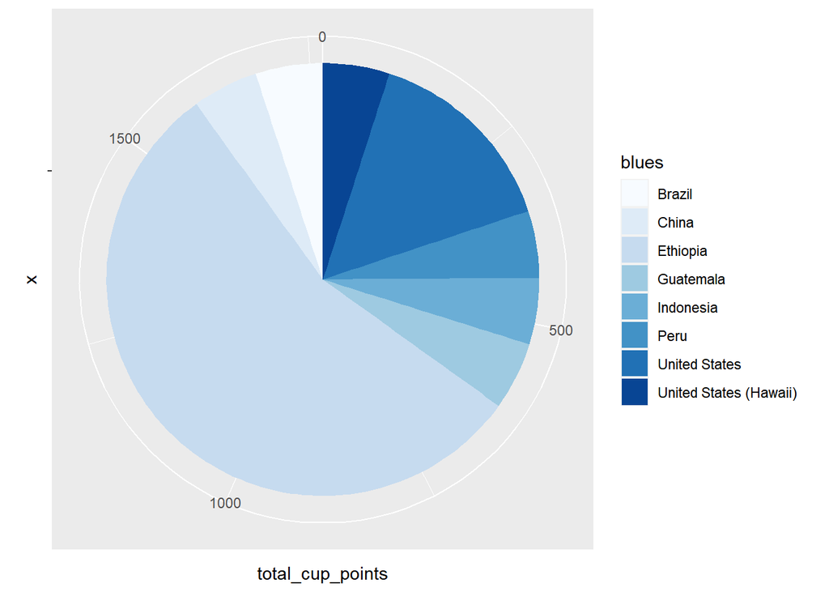

Best country quality-wise

## Altitude v/s Quality

Next, we will will probe into the next question **Does Altitude really affect the quality of the beans produced?** and to explore this we have fitted a linear model. **total_cup points** is the dependent variable and **altitude_mean_meters** as the independent variable. We have considered only the top 1105 observations for constructing the model because 3 extreme values and missing values were rendering a statistically insignificant model with a p-value of more than 0.9. The fitted model returns a p-value of 0.0003 which suggests that the model is statistically significant. Figure 2 shows a positive relationship between altitude and quality of coffee beans produced. Altitude plays an important role in the formation of acidity and bitterness and enhances coffee quality attributes.

Altitude v/s Quality stats

| term | estimate | std.error | statistic | p.value |
| --- | --- | --- | --- | --- |
| (Intercept) | 81.0500388 | 0.3139834 | 258.134802 | 0.0000000 |
| altitude_mean_meters | 0.0008003 | 0.0002221 | 3.604186 | 0.0003271 |

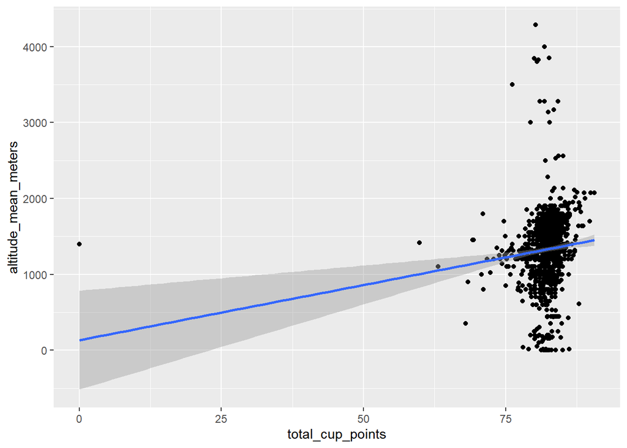

Regression model for Altitude

## Processing Method v/s Quality

```
##                     Df Sum Sq Mean Sq F value Pr(>F)
## processing_method    4     58  14.468   1.978 0.0956 .
## Residuals         1164   8514   7.314
## ---
## Signif. codes:  0 '***' 0.001 '**' 0.01 '*' 0.05 '.' 0.1 ' ' 1
## 170 observations deleted due to missingness
```

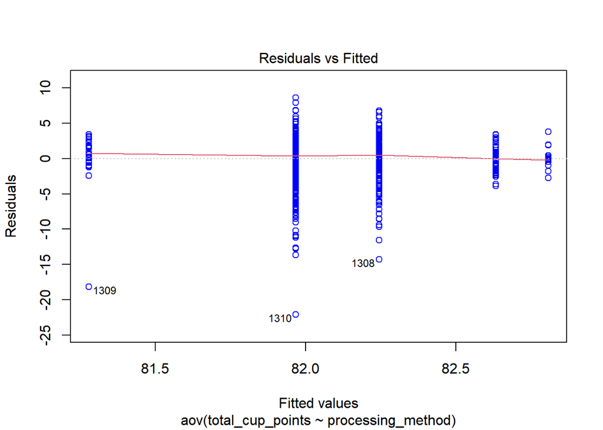

ANOVA test for processing methods vs Quality

## Defects v/s Quality

Defects linear regression model

| term | estimate | std.error | statistic | p.value |
| --- | --- | --- | --- | --- |
| (Intercept) | 82.5885115 | 0.1122747 | 735.593003 | 0.00000 |
| category_one_defects | -0.1106967 | 0.0378995 | -2.920796 | 0.00355 |
| category_two_defects | -0.1252918 | 0.0181894 | -6.888192 | 0.00000 |

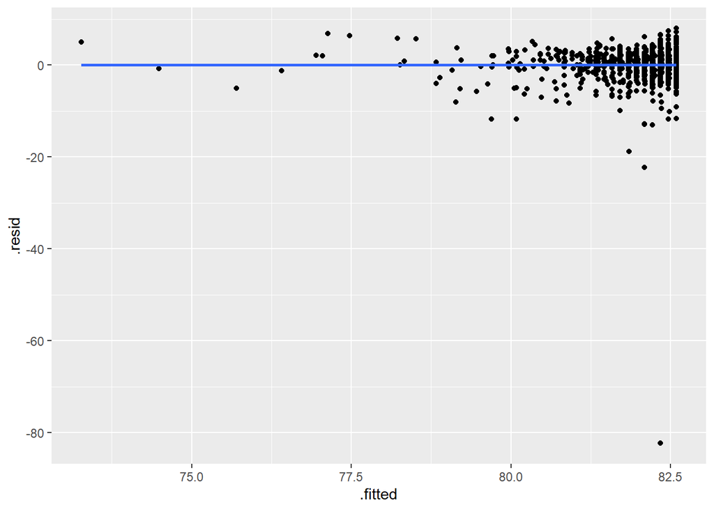

## Individual Criteria v/s Overall Quality

Then we pondered that individual grading criterias should definetely have a positive relationship with the overall quality of the coffee beans and we fitted a multi-variate model with all the individual grading criterias. This turns out to be true as all the individual grading criterias have a p-value of 0 and have a direct impact on the overall quality of the beans produced. As is visible in Figure 5 the residuals fitted against the fitted values lie very close to the 0 line and hence is the best amongst all the models checked. The characteristic *moisture* has a p-value of 0.980 which is a considerably high value than that of the significance level, hence we have decided to remove it from any further analysis.

Individual Grading Summary Stats

| term | estimate | std.error | statistic | p.value |
| --- | --- | --- | --- | --- |
| (Intercept) | -0.0139635 | 0.0113729 | -1.227786 | 0.2197452 |
| aroma | 1.0000542 | 0.0020805 | 480.674771 | 0.0000000 |
| flavor | 0.9991852 | 0.0030111 | 331.832044 | 0.0000000 |
| aftertaste | 1.0024920 | 0.0027487 | 364.720440 | 0.0000000 |
| acidity | 0.9977688 | 0.0021569 | 462.593409 | 0.0000000 |
| body | 1.0006188 | 0.0019991 | 500.545382 | 0.0000000 |
| balance | 1.0025638 | 0.0021023 | 476.896985 | 0.0000000 |
| uniformity | 1.0025238 | 0.0010094 | 993.163820 | 0.0000000 |
| clean_cup | 1.0004330 | 0.0007274 | 1375.419028 | 0.0000000 |
| sweetness | 0.9988919 | 0.0008429 | 1184.999939 | 0.0000000 |
| cupper_points | 0.9968487 | 0.0016226 | 614.354350 | 0.0000000 |
| moisture | -0.0002361 | 0.0094417 | -0.025004 | 0.9800555 |

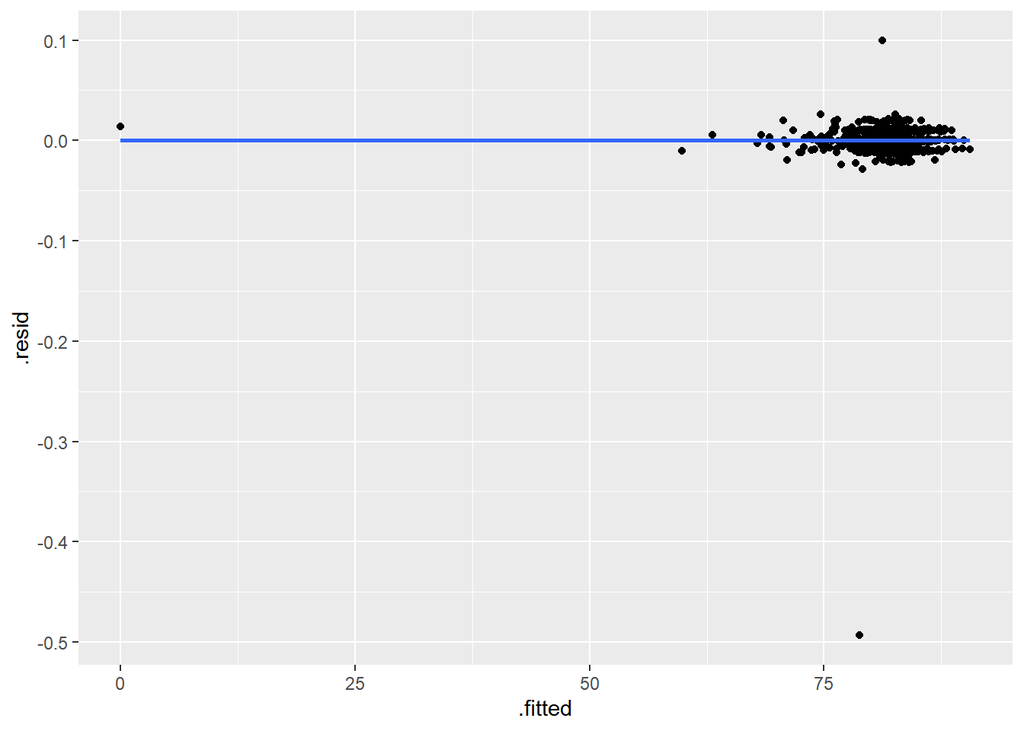

fitted vs resid for Individual grading criteria

## Individual Criteria

Means for different Individual grading criterias

| country_of_origin | ma | mfl | maf | mac | mb | mba | mu | mc | ms | mcu | mm |
| --- | --- | --- | --- | --- | --- | --- | --- | --- | --- | --- | --- |
| Brazil | 7.606667 | 7.548182 | 7.363939 | 7.464545 | 7.532727 | 7.543030 | 9.757273 | 9.69697 | 9.939091 | 7.497576 | 0.0803030 |
| Ethiopia | 8.001429 | 8.154286 | 7.892857 | 8.154286 | 7.930000 | 8.012857 | 9.904286 | 10.00000 | 10.000000 | 8.141429 | 0.0885714 |
| Indonesia | 7.682000 | 7.416000 | 7.200000 | 7.214000 | 7.600000 | 7.230000 | 9.866000 | 10.00000 | 9.866000 | 7.268000 | 0.0700000 |
| Peru | 7.446667 | 7.333333 | 7.223333 | 7.386667 | 7.530000 | 7.446667 | 9.776667 | 10.00000 | 10.000000 | 7.306667 | 0.1100000 |
| United States | 7.790000 | 7.875000 | 7.670000 | 7.875000 | 7.790000 | 7.670000 | 9.665000 | 9.66500 | 8.710000 | 7.835000 | 0.0000000 |

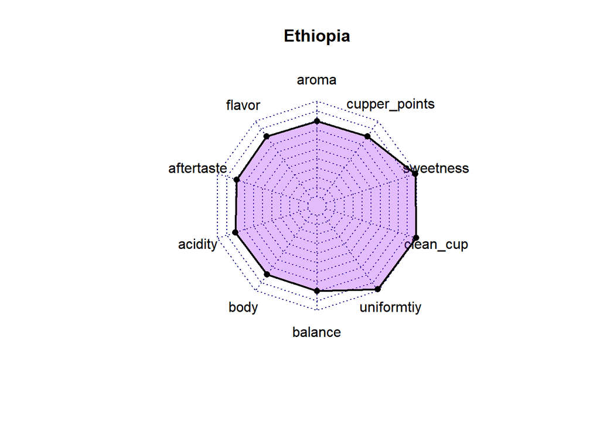

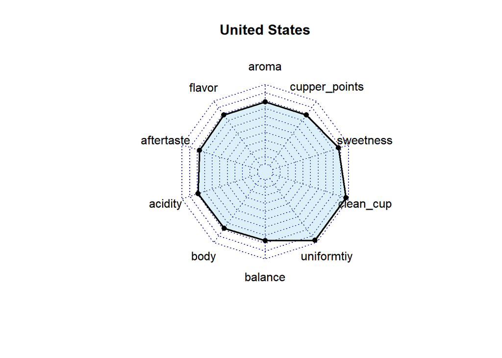

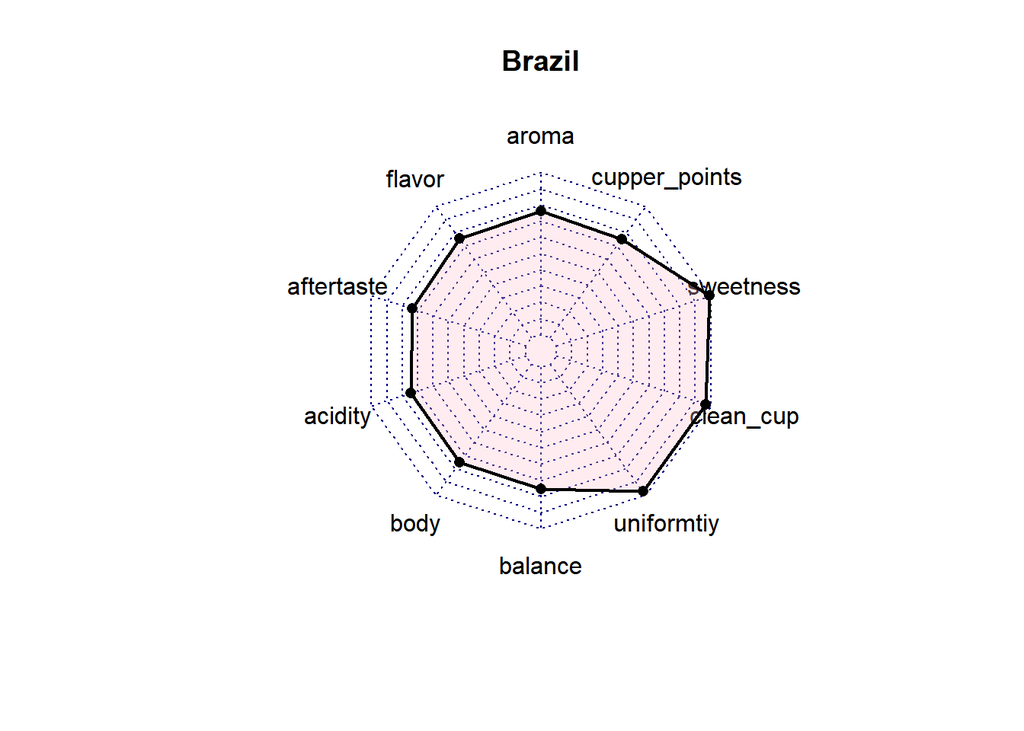

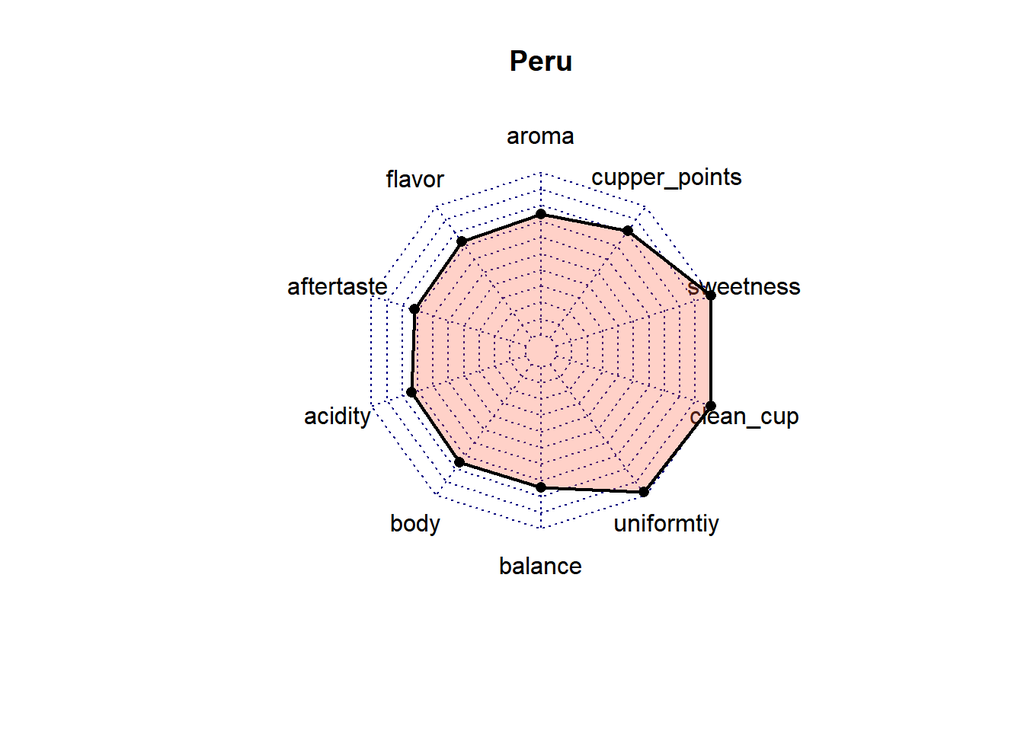

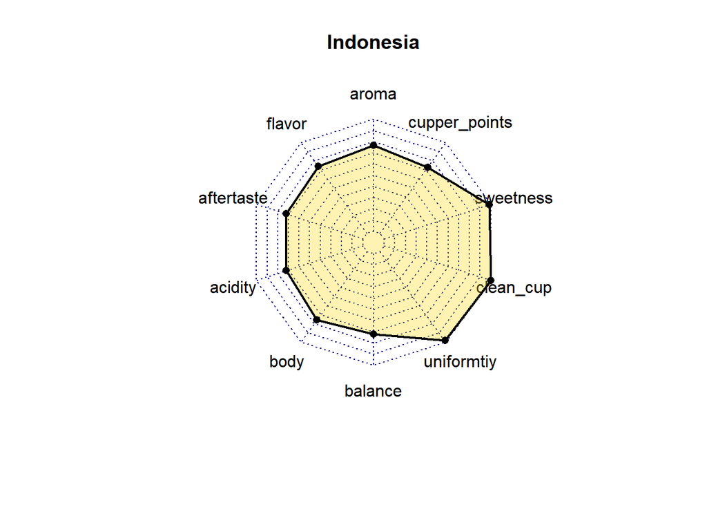

## Leading Regions

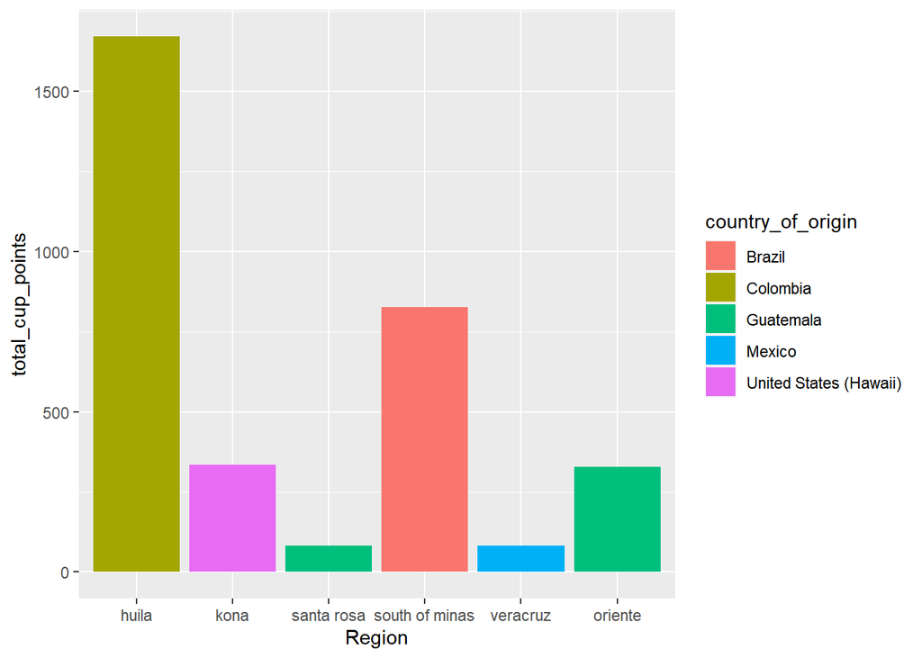

Best Regions for the quality of coffee beans

## Largest Producer

We also observe that Colombia is the largest producer of coffee beans Arabica variant with more than 40000 bags followed by Guatemala and Brazil. We establish using a bar-plot in Figure 9 with y-axis representing the number of bags produced and x-axis representing different countries. The Figure shows the top-6 coffee bean producing countries.

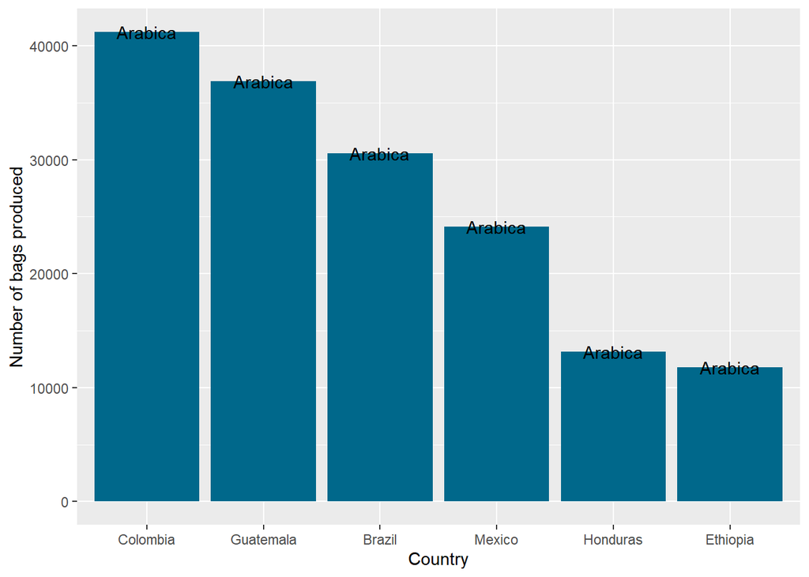

Largest producer country-wise

# References

- The dataset was taken from (https://github.com/rfordatascience/tidytuesday/blob/master/data/2020/2020-07-07/readme.md)
- Further inferences were drawn into the data taking help from (https://database.coffeeinstitute.org/coffee/357789/grade)
- Cerda, R., Allinne, C., Gary, C., Tixier, P., Harvey, C. A., Krolczyk, L., … & Avelino, J. (2017). Effects of shade, altitude and management on multiple ecosystem services in coffee agroecosystems. European Journal of Agronomy, 82, 308-319.
- The data is in: Ethiopia has the best coffee. (2020). Retrieved 27 August 2020, from https://towardsdatascience.com/the-data-speak-ethiopia-has-the-best-coffee-91f88ed37e84
- En.wikipedia.org. 2020. Coffee Bean. [online] Available at: https://en.wikipedia.org/wiki/Coffee_bean [Accessed 27 August 2020].